# Compute probability and cumulative distribution functions

Nicolas Rode

27-March-2024

```r
library(ggplot2)
library(dplyr)
library(ggpubr)
```

# 1 Poisson distribution

Used to model count data where the events occur randomly and independently at a constant rate Range: {0, 1, 2, 3, …} Examples: Number of accidents in a day, number of calls received by a customer service center Probability mass function: P(X=xi) = (exp^(-λ) λ^xi) / xi! Graph: distribution skewed to the right Assumptions: The mean and variance of the distribution are equal Equations: E(X) = Var(X) = λ

## 1.1 PDF

### 1.1.1 Compute PDF

```r
## Define function
compute_pdf <- function(lambda, xi){
  (exp(-lambda)*lambda^xi) / factorial(xi)
}

## Compute the probability of observing zero larvae
compute_pdf(lambda=1, xi=0)
```

```
## [1] 0.3678794
```

### 1.1.2 Plot PDF

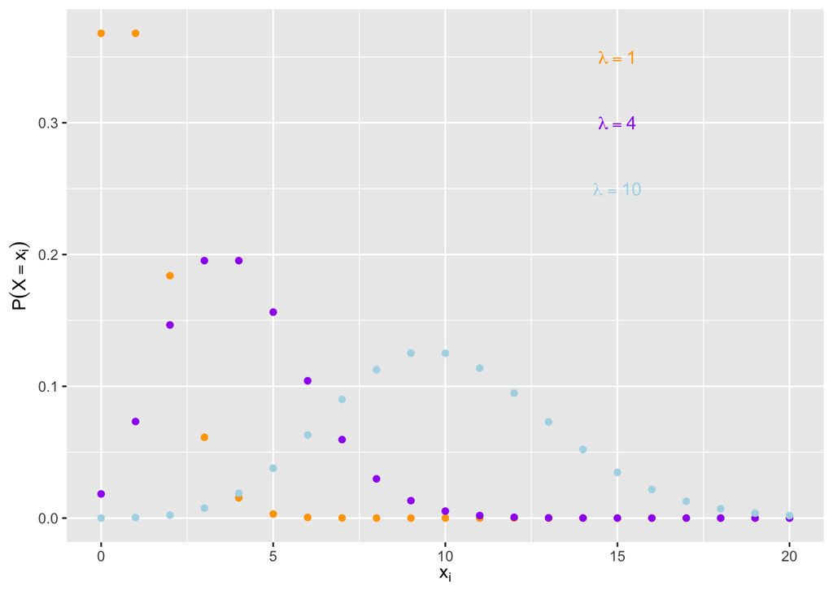

```r
p <- ggplot(data.frame(x = 0:20), aes(x)) +
    stat_function(geom = "point", n = 21, fun = dpois, args = list(lambda = 1), color = "orange")+
    stat_function(geom = "point", n = 21, fun = dpois, args = list(lambda = 4), color = "purple")+
    stat_function(geom = "point", n = 21, fun = dpois, args = list(lambda = 10), color = "lightblue")+
    annotate("text", x=15, y=0.35, label= "lambda == 1", parse = TRUE, color = "orange")+
    annotate("text", x=15, y=0.3, label= "lambda == 4", parse = TRUE, color = "purple")+
    annotate("text", x=15, y=0.25, label= "lambda == 10", parse = TRUE, color = "lightblue")+
  xlab(bquote(x[i]))+
  ylab(bquote(P(X==x[i])))
p
```

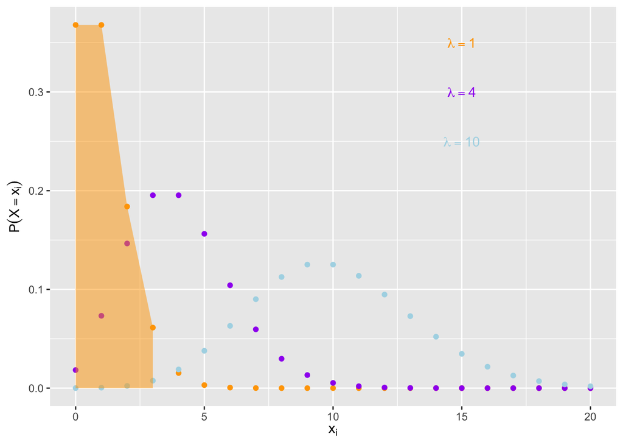

```r
p1 <- p +
  stat_function(geom = "area", aes(x), n = 4, fun = dpois, args = list(lambda = 1), xlim = c(0, 3), fill = "orange", alpha = 0.5)
p1
```

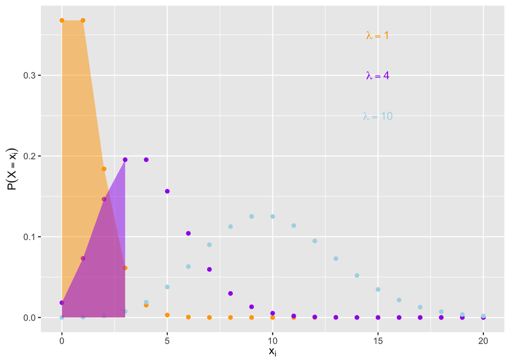

```r
p2 <- p1 +
  stat_function(geom = "area", aes(x), n = 4, fun = dpois, args = list(lambda = 4), xlim = c(0, 3), fill = "purple", alpha = 0.5)
p2
```

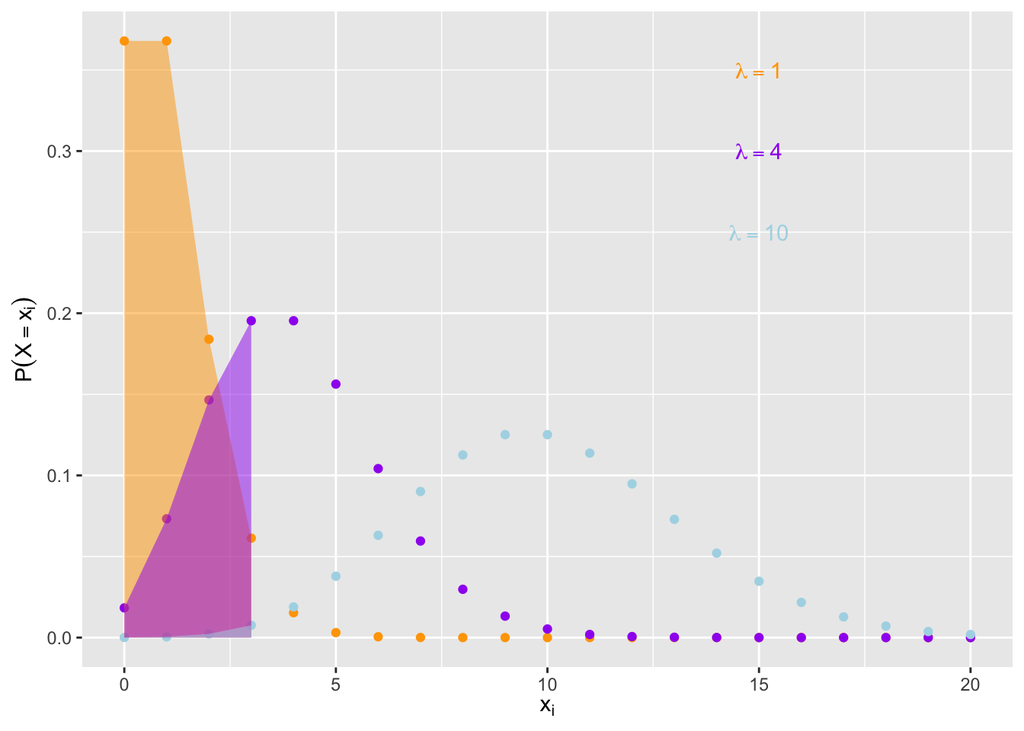

```r
p3 <- p2 +
  stat_function(geom = "area", aes(x), n = 4, fun = dpois, args = list(lambda = 10), xlim = c(0, 3), fill = "lightblue", alpha = 0.5)
p3
```

## CDF

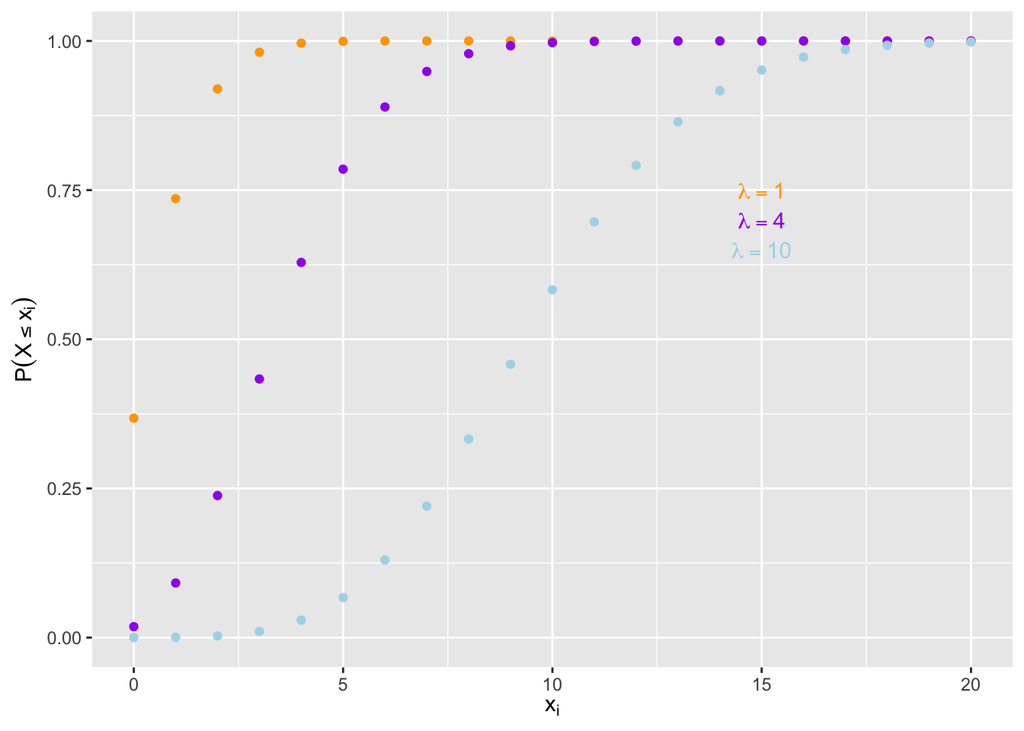

```r
p4 <- ggplot(data.frame(x = 0:20), aes(x)) +
    stat_function(geom = "point", n = 21, fun = ppois, args = list(lambda = 1), color = "orange")+
    stat_function(geom = "point", n = 21, fun = ppois, args = list(lambda = 4), color = "purple")+
    stat_function(geom = "point", n = 21, fun = ppois, args = list(lambda = 10), color = "lightblue")+
    annotate("text", x=15, y=0.75, label= "lambda == 1", parse = TRUE, color = "orange")+
    annotate("text", x=15, y=0.7, label= "lambda == 4", parse = TRUE, color = "purple")+
    annotate("text", x=15, y=0.65, label= "lambda == 10", parse = TRUE, color = "lightblue")+
  xlab(bquote(x[i]))+
  ylab(bquote(P(X<=x[i])))
p4
```

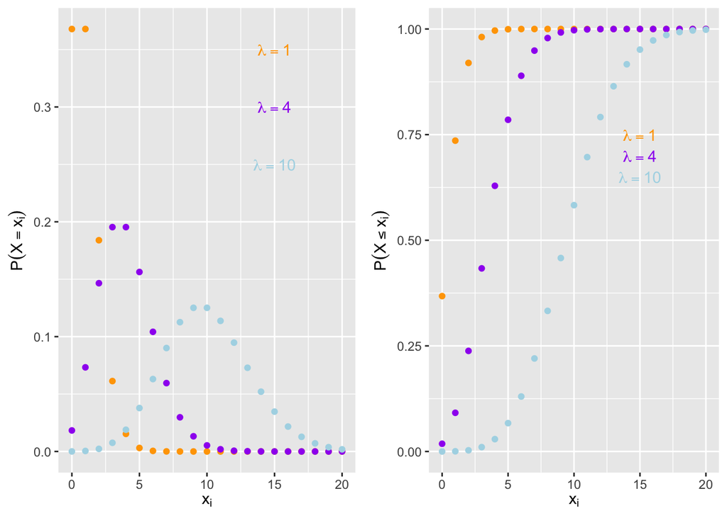

```r
ggarrange(p, p4, ncol = 2, nrow = 1)
```

## Simulations ### Plot distribution

```r
# Simulate data with rpois
set.seed(123)  # for reproducibility
data <- data.frame(y=rpois(n = 5, lambda = 1))

# If the minimum value is zero or a positive integer, then the variable might be a count variable.
min(data)  # check minimum value
```

```
## [1] 0
```

```r
## Check probability of each type of event
table(data)  # count occurrences of each value
```

```
## y
## 0 1 2 3
## 1 1 2 1
```

```r
prop.table(table(data))  # calculate proportion of occurrences
```

```
## y
##   0   1   2   3
## 0.2 0.2 0.4 0.2
```

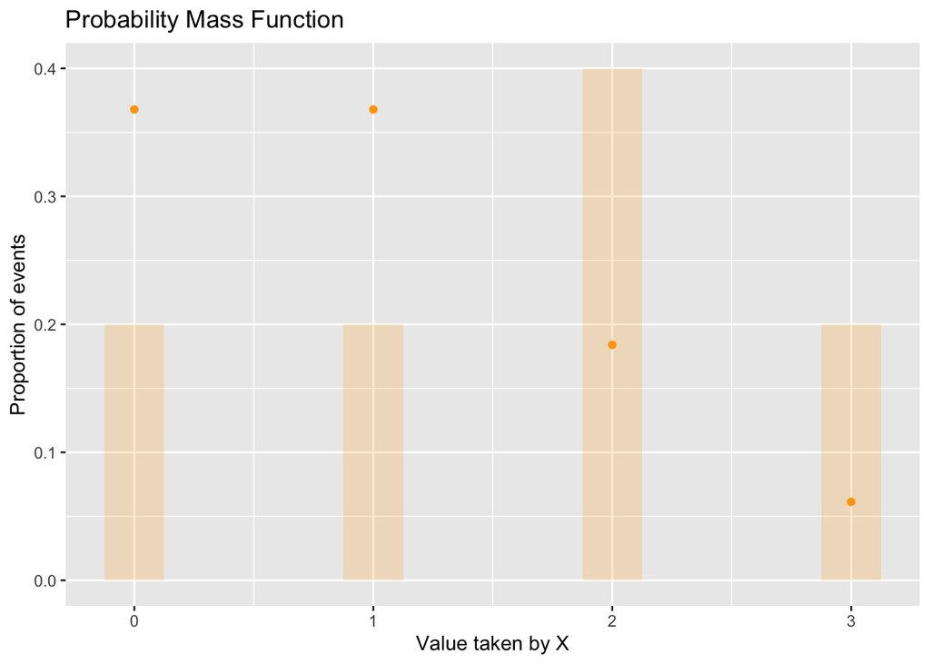

```r
## Plot observed distribution and expected PDF
p <- data %>%
  ggplot2::ggplot(aes(y)) +
  geom_histogram(aes(y = after_stat(count / sum(count))), fill = "orange", alpha = 0.2, binwidth = 0.25)+
  labs(title = "Probability Mass Function", x = "Value taken by X", y = "Proportion of events") +
  stat_function(geom = "point", n = 4, fun = dpois, args = list(lambda = 1), color = "orange")
p
```

```r
# check mean and variance are equal or not
mean(data$y)  # calculate mean
```

```
## [1] 1.6
```

```r
var(data$y)  # calculate variance
```

```
## [1] 1.3
```

### 1.1.3 Compute ML by hand

```r
dpois(x=0, lambda = 1, log=TRUE)
```

```
## [1] -1
```

```r
## Compute the product
prod(dpois(data$y, lambda = 0.5))
```

```
## [1] 1.336019e-05
```

```r
## Possible values of lambda
possible.lambda <- seq(0, 3, by=0.1)

## Write function
compute_prob <- function(lambda, sim.data=data){
  prod(dpois(sim.data$y, lambda = lambda))
}

compute_prob(lambda=1, sim.data=data)
```

```
## [1] 0.0002807478
```

```r
compute_prob(lambda=1.6, sim.data=data)
```

```
## [1] 0.0006003338
```

```r
compute_prob(lambda=2, sim.data=data)
```

```
## [1] 0.0004842659
```

```r
## Apply function over each possible value
sapply(possible.lambda, compute_prob)
```

```
##  [1] 0.000000e+00 2.527211e-10 3.924047e-08 6.099821e-07 3.695555e-06
##  [6] 1.336019e-05 3.484298e-05 7.253413e-05 1.280356e-04 1.992524e-04
## [11] 2.807478e-04 3.650149e-04 4.440909e-04 5.110006e-04 5.607273e-04
## [16] 5.906228e-04 6.003338e-04 5.913942e-04 5.666547e-04 5.296878e-04
## [21] 4.842659e-04 4.339614e-04 3.818835e-04 3.305407e-04 2.818025e-04
## [26] 2.369342e-04 1.966741e-04 1.613331e-04 1.308972e-04 1.051242e-04
## [31] 8.362605e-05
```

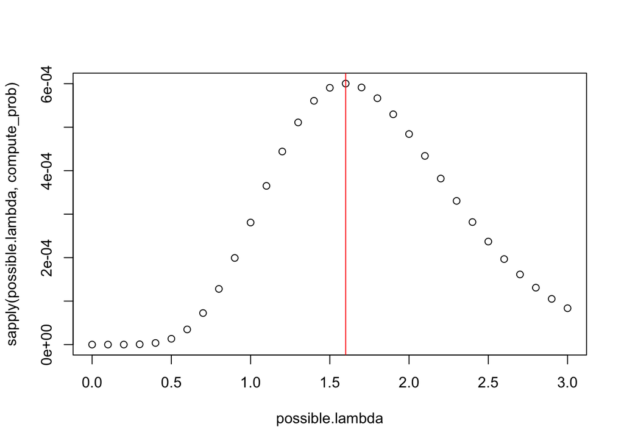

```r
## Plot likelihood profile
plot(x=possible.lambda, y=sapply(possible.lambda, compute_prob))
abline(v=mean(data$y), col='red')
```

### 1.1.4 Compute MLE using the optim function in R

```r
## Write the  the log-likelihood function
loglik <- function(sim.data=data$y, lambda) {
sumlogprob <- sum(dpois(sim.data, lambda=lambda, log = TRUE))
return(sumlogprob)}

## Example of values
loglik(lambda=1, sim.data=data$y)
```

```
## [1] -8.178054
```

```r
loglik(lambda=1.6, sim.data=data$y)
```

```
## [1] -7.418025
```

```r
loglik(lambda=2, sim.data=data$y)
```

```
## [1] -7.632876
```

```r
## Based on Bloker 2008 p173 (use control option to perform maximization)
MLest <- optim(fn = loglik, par=c(lambda = 1), sim.data=data$y,  method = "BFGS", control = list(fnscale = -1))
MLest$par
```

```
## lambda
##    1.6
```

```r
MLest$value
```

```
## [1] -7.418025
```

### 1.1.5 Compute MLE using the glm function in R

```r
# fit into model for poisson
m0 <- glm(y ~ 1, family = poisson, data=data)  # fit Poisson regression model
summary(m0)  # display model summary
```

```
##
## Call:
## glm(formula = y ~ 1, family = poisson, data = data)
##
## Coefficients:
##             Estimate Std. Error z value Pr(>|z|)
## (Intercept)   0.4700     0.3536   1.329    0.184
##
## (Dispersion parameter for poisson family taken to be 1)
##
##     Null deviance: 4.6168  on 4  degrees of freedom
## Residual deviance: 4.6168  on 4  degrees of freedom
## AIC: 16.836
##
## Number of Fisher Scoring iterations: 5
```

```r
logLik(m0)
```

```
## 'log Lik.' -7.418025 (df=1)
```

```r
coef(m0)
```

```
## (Intercept)
##   0.4700036
```

```r
exp(coef(m0))
```

```
## (Intercept)
##         1.6
```

# 2 Normal distribution

Graph: Bell-shaped curve Assumptions: Data is normally distributed and has equal variance Equations: E(X) = µ, Var(X) = σ²

# 3 Binomial distribution

Used to model the probability of a binary outcome (success or failure) in a fixed number of trials Range: {0, 1, 2, …, n} Examples: Flipping a coin a certain number of times and counting the number of heads, the number of defective items in a sample of products Probability mass function: P(X=k) = (n choose k) p^k (1-p)^(n-k) Graph: Symmetrical distribution Assumptions: Trials are independent and have the same probability of success Equations: E(X) = np, Var(X) = np(1-p)